# COSC-523: Lab 08

**Daniel Carter**

[Notebook Link](https://colab.research.google.com/drive/1Mkb8cEUR16JPkBu-7KB-8n6kRXW4UIHX?usp=sharing)

## Getting Started

Follow the instructions below to copy this notebook and to perform some initial setup.

1. Copy this notebook by selecting `File > Save a copy in Drive`.
2. A new window should open for the copied notebook. Move the new notebook to your course folder in Google Drive by selecting `File > Move` and then selecting the desired folder.
3. Update the name of the notebook by removing "Copy of" and replacing "Username" with your actual username.
4. Update the first cell in the notebook by specifying your course number (423 or 523) and by replacing "**Student Name**" with your actual name.
5. Do not edit the line that says `PLACEHOLDER_FOR_NOTEBOOK_LINK`. This will be used by the [Notebook Renderer](https://colab.research.google.com/drive/1CJTipys46ldZxJFwnt7XbdjQUfkmoXeU?usp=sharing) tool to insert a link to your Colab notebook.
6. Enable link sharing for your notebook.

# Part 1: Understanding the Fundamentals of 3D Computer Vision

Instructions:

Answer the following questions to understand the basic concepts of 3D Computer Vision:

1. What is Stereo Vision and how is it used in 3D Computer Vision? Explain the process of stereo vision, including how two images (from different viewpoints) can be used to estimate depth information.
2. What is Depth Estimation in 3D vision and how does it differ from traditional image processing? Discuss methods used to estimate the depth of objects in a scene from 2D images.
3. What is Structure from Motion (SfM) and how is it used to reconstruct 3D scenes from multiple 2D images? Explain the concept of Structure from Motion and its relationship with camera calibration and feature matching.
4. How does Point Cloud Visualization help in 3D reconstruction? Describe how point clouds are created and visualized, and how they contribute to reconstructing 3D environments or objects.
5. What are some common methods used for 3D Object Recognition? Discuss various 3D object recognition techniques such as using depth maps, point clouds, or volumetric representations.
1. What is Stereo Vision and how is it used in 3D Computer Vision?
- Stereo vision uses two photos from different angles to figure out depth, like how human eyes work. It helps create 3D models for things like self-driving cars or 3D maps.
2. What is Depth Estimation in 3D vision and how does it differ from traditional image processing?
- Depth estimation figures out how far objects are from a camera using 2D images, unlike regular image processing that only looks at colors or shapes. It uses methods like stereo vision or AI to guess distances.
3. What is Structure from Motion (SfM) and how is it used to rebuild 3D scenes from multiple 2D images?
- Structure from Motion builds 3D scenes by tracking how a camera moves through multiple 2D photos and matching key points. It’s used for things like 3D mapping in archaeology or robotics.
4. How does Point Cloud Visualization help in 3D reconstruction?
- Point clouds are 3D data points from scans or depth images, shown with tools like MeshLab to rebuild objects or places. They provide the spatial info needed to create detailed 3D models.
5. What are some common methods used for 3D Object Recognition?
- 3D object recognition uses depth maps, point clouds, or 3D models to identify objects by their shape and structure. It’s used in robotics or augmented reality to recognize things accurately.

# Part 2: Implementing Stereo Vision for Disparity Map

Instructions:

1. Upload the 2 left and right images named im0 and im1. Since these images are huge, it is best to resize both these images to half their size.
2. Create a stereo vision object using StereoSGBM. Tune parameters like numDisparities, blockSize, speckleWindowSize, and speckleRange.
3. Mention in a comment why you chose the values that you did for the above mentioned parameters
4. Create a stereo vision object using StereoBM_create. Use different values for numDisparities and blockSize than what is provided in the Module
5. Visualize the images and the disparity map

```python
#import necessary libraries
import cv2
import numpy as np
import matplotlib.pyplot as plt
from mpl_toolkits.mplot3d import Axes3D
```

```python
#load in each image
left = cv2.imread('im0.png', cv2.IMREAD_GRAYSCALE)
right = cv2.imread('im1.png', cv2.IMREAD_GRAYSCALE)

#Get size of each img
print(left.shape)
print(right.shape)
```

```
(1080, 1920)
(1080, 1920)
```

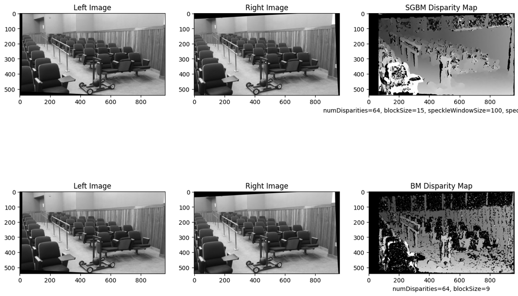

```python
#Resize to half of their size
left = cv2.resize(left, (0,0), fx=0.5, fy=0.5)
right = cv2.resize(right, (0,0), fx=0.5, fy=0.5)

#Create a stereo vision object using StereoSGBM
stereoSGBM = cv2.StereoSGBM_create(
    minDisparity=1,
    numDisparities=64,
    blockSize=15,
    speckleWindowSize=100,
    speckleRange=32,
)# Chose the valuse based on the modules, documentation, and gemini suggestions

#Disparity Map
disparity_map1 = stereoSGBM.compute(left, right)

#normalize
disparity_map1 = cv2.normalize(disparity_map1, None, alpha=0, beta=255, norm_type=cv2.NORM_MINMAX)
disparity_map1 = disparity_map1.astype(np.uint8)

#Create a stereo vision object using StereoBM_Create
stereoBM = cv2.StereoBM_create(
    numDisparities=64,
    blockSize=9
)

#Disparity Map
disparity_map2 = stereoBM.compute(left, right)

#Normalize
disparity_map2 = cv2.normalize(disparity_map2, None, alpha=0, beta=255, norm_type=cv2.NORM_MINMAX)
disparity_map2 = disparity_map2.astype(np.uint8)

#Visualize all the images and disparity maps
fig, axs = plt.subplots(2, 3, figsize=(15, 10))
axs[0, 0].imshow(left, cmap='gray')
axs[0, 0].set_title('Left Image')
axs[0, 1].imshow(right, cmap='gray')
axs[0, 1].set_title('Right Image')
axs[0, 2].imshow(disparity_map1, cmap='gray')
axs[0, 2].set_title('SGBM Disparity Map')
axs[0, 2].set_xlabel('numDisparities=64, blockSize=15, speckleWindowSize=100, speckleRange=32')
axs[1, 0].imshow(left, cmap='gray')
axs[1, 0].set_title('Left Image')
axs[1, 1].imshow(right, cmap='gray')
axs[1, 1].set_title('Right Image')
axs[1, 2].imshow(disparity_map2, cmap='gray')
axs[1, 2].set_title('BM Disparity Map')
axs[1, 2].set_xlabel('numDisparities=64, blockSize=9')
plt.show()
```

# Part 3: Depth Estimation

Instructions:

Using the disparity map from StereoBM, we will now do depth estimation.

1. Before we do depth estimation, lets look at the camera caliberation information that is associated with the images we used in Part 2. Use the file camera caliberation info to find fx and fy i.e., focal length of the camera that was used to take the images we used in Part 2:
2. From the same sheet, get the baseline value and make sure it is in meters.
3. Apply a minimum disparity constraint to avoid unrealistic depth values:  
   set a variable: min_disparity=1
4. Calculate the depth map, but modify the denominator expression to choose the max value between disparity_map and min_disparity (you can use np.maximum). This avoid unrealistic depth values
5. Clip the depth map to reasonable values (e.g., between 0.1 and 10)
6. Display the Depth Map

```
Min depth BEFORE clipping: 3613.663818359375
Max depth BEFORE clipping: 921484.25
Mean depth BEFORE clipping: 460671.34375
Min depth AFTER clipping: 3613.663818359375
Max depth AFTER clipping: 10000.0
Mean depth AFTER clipping: 8297.5283203125
```

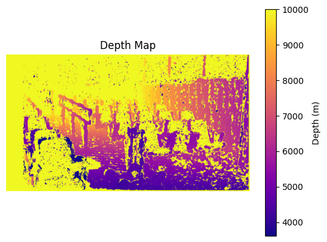

```python
#find the focal length from the excel sheet
focal_length = 1729.48
baseline = 532.81
min_disparity = 1
#use desparity map from stereobm
depth_map = (focal_length * baseline) / (np.maximum(disparity_map2.astype(np.float32), min_disparity))

# Print min, max, and mean of depth_map to understand value distribution BEFORE clipping
print(f"Min depth BEFORE clipping: {np.min(depth_map)}")
print(f"Max depth BEFORE clipping: {np.max(depth_map)}")
print(f"Mean depth BEFORE clipping: {np.mean(depth_map)}")

depth_map = np.clip(depth_map, 3000, 10000) # Adjusted clipping range

# Print min, max, and mean of depth_map to understand value distribution AFTER clipping
print(f"Min depth AFTER clipping: {np.min(depth_map)}")
print(f"Max depth AFTER clipping: {np.max(depth_map)}")
print(f"Mean depth AFTER clipping: {np.mean(depth_map)}")

#I was using 0.1-10 and all the values were being sent to 10 making it one color. Made adjustments to be able to better see it


#Visualize just the depth map
plt.imshow(depth_map, cmap='plasma')
plt.title('Depth Map')
plt.colorbar(label='Depth (m)')
plt.axis('off')
plt.show()
```

# Part 4: Visualizing Point Clouds from depth estimation

Instructions:

We will now use the depth map we just calculated to create a 3D point cloud. Keep in mind that the final display may not look entirely accurate as the mplot3d module has limited capability.  
Here are the steps:

1. Import the necessary libraries and modules: numpy, cv2, matplotlib and Axes3D
2. camera caliberation info, to define the following 4 variables:  
   fx = ____ # optical center in the x-direction  
   fy = ____ # optical center in the y-direction  
   cx = ____  
   cy = ____
3. Use .shape to store the height and width of the depth_map into variables h and w
4. To convert the pixel coordinates to 3D coordinates, you need to generate a grid of pixel coordinates. Use np.meshgrid to create 2D arrays of pixel indices for the x and y coordinates
5. Using the camera intrinsic parameters, convert the 2D pixel coordinates (x, y) into 3D world coordinates: where Z is the depth map and x and y are given by the formula:  
   X = (x - cx) * Z / fx # Convert to 3D world coordinates in X  
   Y = (y - cy) * Z / fy # Convert to 3D world coordinates in Y
6. Flatten the X, Y, and Z arrays into 1D arrays.
7. The visualization code is given to you

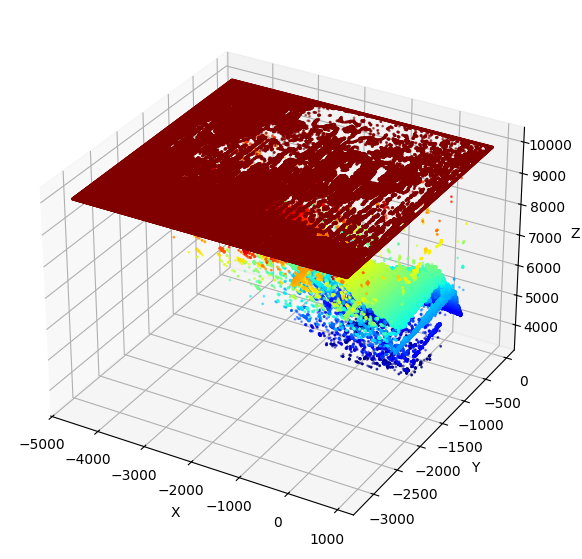

```python
#2
fx = 1729.48
fy = 1729.48
cx = 800.77
cy = 551.55

#3
h = depth_map.shape[0]
w = depth_map.shape[1]

#4
x, y = np.meshgrid(np.arange(w), np.arange(h))

#5
Z = depth_map
X = (x - cx) * Z / fx
Y = (y - cy) * Z / fy

#6
X = X.flatten()
Y = Y.flatten()
Z = Z.flatten()

#7
fig = plt.figure(figsize=(10, 7))
ax = fig.add_subplot(111, projection='3d')
ax.scatter(X, Y, Z, s=1, c=Z, cmap='jet')  # Color by depth
ax.set_xlabel('X')
ax.set_ylabel('Y')
ax.set_zlabel('Z')
plt.show()
```

# Part 5: 3D Object Recognition Using Point Cloud Data

Instructions:

We will now use the point cloud data to perform 3D object recognition:

1. Stack the X,Y and Z values using np.column_stack. This gives you the points variable
2. Use RANSAC to apply plane segmentation
3. Use DBSCAN to cluster the objects
4. Visualize the recognized object in 3D.

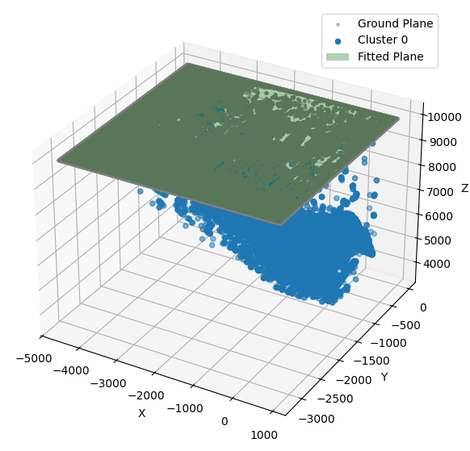

```python
#stack x,y,and z
stack = np.column_stack((X, Y, Z))

#Use RANSAC to apply plane segmentation
from sklearn.linear_model import RANSACRegressor
ransac = RANSACRegressor(residual_threshold=0.02)
ransac.fit(stack[:, :2], stack[:, 2])
inliers = ransac.inlier_mask_
outliers = np.logical_not(inliers)

#Use DBSCAN to cluster objects
from sklearn.cluster import DBSCAN
dbscan = DBSCAN(eps=0.08, min_samples=20)
clusters = dbscan.fit_predict(stack[outliers])

#Visualize
fig = plt.figure(figsize=(10, 7))
ax = fig.add_subplot(111, projection='3d')

#plot ground plane
ax.scatter(stack[inliers, 0], stack[inliers, 1], stack[inliers, 2], c='gray', label='Ground Plane', s=5, alpha=0.5)

#plot cluster
unique_labels = set(clusters)
colors = plt.cm.get_cmap('tab20', len(unique_labels))
for label in unique_labels:
  cluster_points = stack[outliers][clusters == label]
  ax.scatter(cluster_points[:, 0], cluster_points[:, 1], cluster_points[:, 2], label=f'Cluster {label + 1}', s=20, color=colors(label))

#Plot fitted plane
xx,yy = np.meshgrid(np.linspace(stack[:, 0].min(), stack[:, 0].max(), 100), np.linspace(stack[:, 1].min(), stack[:, 1].max(), 100))
zz = ransac.predict(np.column_stack((xx.ravel(), yy.ravel())))
zz = zz.reshape(xx.shape)
ax.plot_surface(xx, yy, zz, color='g', alpha=0.3, label='Fitted Plane')

ax.set_xlabel('X')
ax.set_ylabel('Y')
ax.set_zlabel('Z')
plt.legend()
plt.show()
```

# Submission Instructions

1. Perform a Restart and Run All by clicking **Tools > Restart session and run all**.
2. Copy the link to your notebook by clicking **Share > Copy Link**.
3. Paste the copied link into the `notebook_url` field in the [Notebook Renderer](https://colab.research.google.com/drive/1CJTipys46ldZxJFwnt7XbdjQUfkmoXeU?usp=sharing) tool and then execute the cell to render the notebook.
4. The Notebook Renderer will open up a save file dialog. Save the resulting HTML file yo your local machine.
5. Submit the HTML file to Canvas.